# Simulating the impact of delays on epidemic curves

Thibaut Jombart

2021-11-18

# Rationale of the simulations

Here we use a simple model to simulate epidemic growth for 30 days so that:

- the initial number of cases on day 0 is 10
- incidence of new cases multiplies by a average growth rate of 1.1 each day
- cases on a given day are generated from a Poisson distribution

Once we have simulated the number of cases on days 0, 1, 2, …, 30, we generate corresponding dates of infection for every case. From there, we will simulate the dates of symptom onset and of reporting of the case using simple uniform distributions.

# Simulating the number of cases

The code below implements the approach outlined above:

1. compute the average number of daily cases with 10 initial cases and a daily growth rate of 1.1
2. use this average to draw cases from a Poisson distribution using `rpois`
3. create a vector of dates of infection of every cases, and store it in a `tibble`

```r
## load useful packages
library(tidyverse)
library(incidence2)


## step 1: compute average cases
days <- 0:30
r <- 0.1
mean_cases <- 10 * (1 + r) ^(days)
mean_cases
```

```
##  [1]  10.00000  11.00000  12.10000  13.31000  14.64100  16.10510  17.71561
##  [8]  19.48717  21.43589  23.57948  25.93742  28.53117  31.38428  34.52271
## [15]  37.97498  41.77248  45.94973  50.54470  55.59917  61.15909  67.27500
## [22]  74.00250  81.40275  89.54302  98.49733 108.34706 119.18177 131.09994
## [29] 144.20994 158.63093 174.49402
```

```r
## step 2: draw cases from Poisson
cases <- rpois(n = length(mean_cases), lambda = mean_cases)


## step 3: create dates of infection for these cases
date_infection <- rep(days, cases)
data <- tibble(date_infection)
data
```

```
## # A tibble: 1,875 × 1
##    date_infection
##             <int>
##  1              0
##  2              0
##  3              0
##  4              0
##  5              0
##  6              0
##  7              0
##  8              0
##  9              0
## 10              0
## # … with 1,865 more rows
```

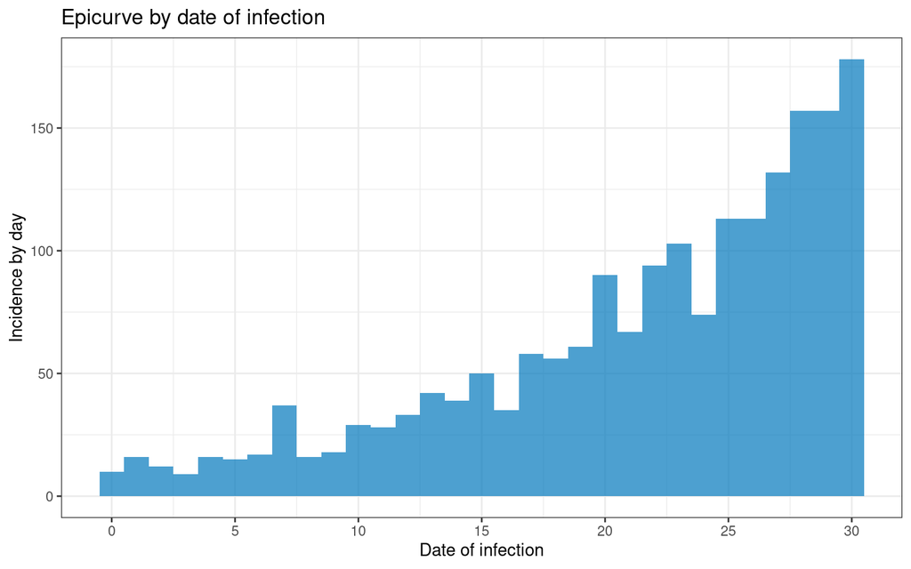

```r
## make incidence object and plot
data %>%
  incidence(date_infection) %>%
  plot() +
  labs(title = "Epicurve by date of infection",
       x = "Date of infection")
```

# Simulating onset of symptoms and reporting

Here, we use will add random delays to each date of infection to simulate the dates of onset of symptoms, and the dates of reporting (when cases are notified in the surveillance system). We use simple distributions for the delays:

- *incubation period*: delays from 1 to 14 days, uniformly distributed
- *notification delay*: delays from 1 to 4 days, uniformly distributed

The custom function `sim_delay` will implement these distributions.

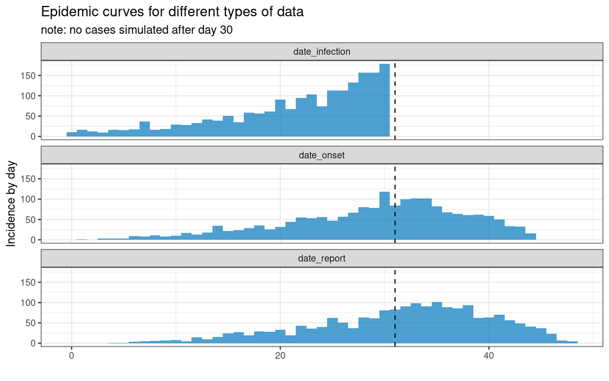

```r
#  Function simulating incubation times

## This uses uniform delays with specified min and max
## `n` is the number of delays to simulate
sim_delay <- function(n, min_delay = 1, max_delay = 10) {
  delays <- seq(min_delay, max_delay, by = 1L)
  sample(delays, n, replace = TRUE)
}

# apply the function to create new variables for dates of onset and reporting
data <- data %>%
  mutate(date_onset = date_infection + sim_delay(n(), max_delay = 14),
         date_report = date_onset + sim_delay(n(), max_delay = 4)
         )


# visualise the 3 epidemic curves
## reformat data in the 'long' format
data_long <- data %>%
  pivot_longer(everything(), names_to = "event", values_to = "date")

## calculate incidence by type of date ('event') and plot results
data_long %>%
  incidence(date, groups = event) %>%
  facet_plot(nrow = 3) +
  geom_vline(xintercept = 31, linetype = 2) +
  labs(title = "Epidemic curves for different types of data",
       subtitle = "note: no cases simulated after day 30")
```

# Illustrating the impact of delays

In this part, we show the impact of the delays (incubation period and reporting) on the epidemic curves by date of onset at various stages of the epidemic: on days 10, 20, and 30.

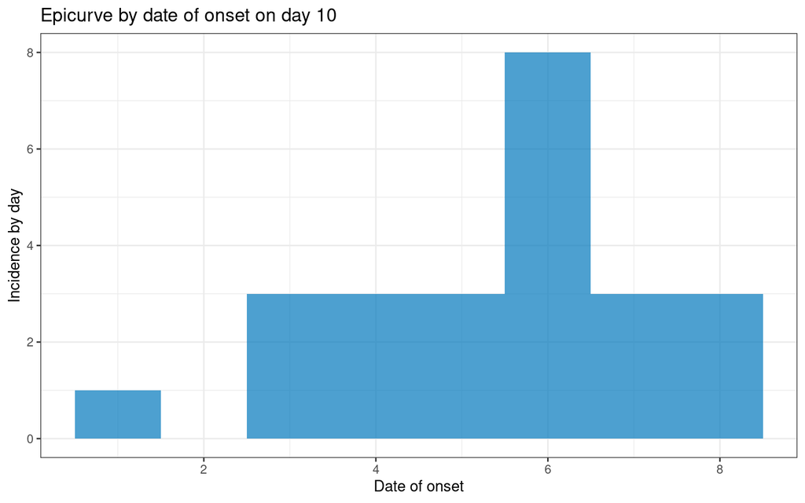

```r
# check the epicurves for reported cases on various days
## on day 10
data %>%
  filter(date_report < 10) %>%
  incidence(date_onset) %>%
  plot() +
  labs(title = "Epicurve by date of onset on day 10",
       x = "Date of onset")
```

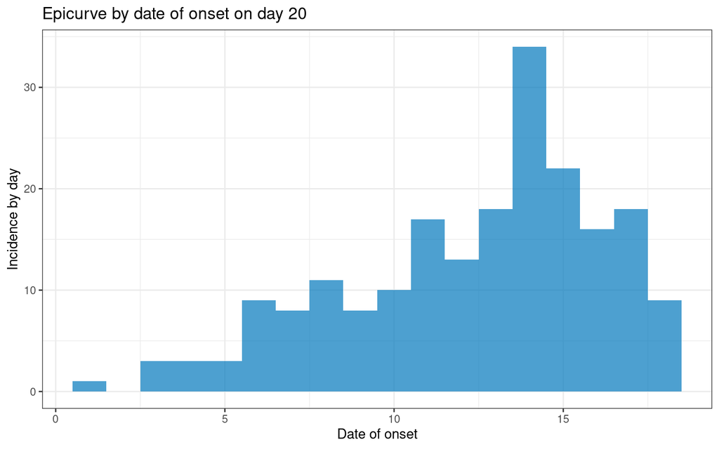

```r
## on day 20
data %>%
  filter(date_report < 20) %>%
  incidence(date_onset) %>%
  plot() +
  labs(title = "Epicurve by date of onset on day 20",
       x = "Date of onset")
```

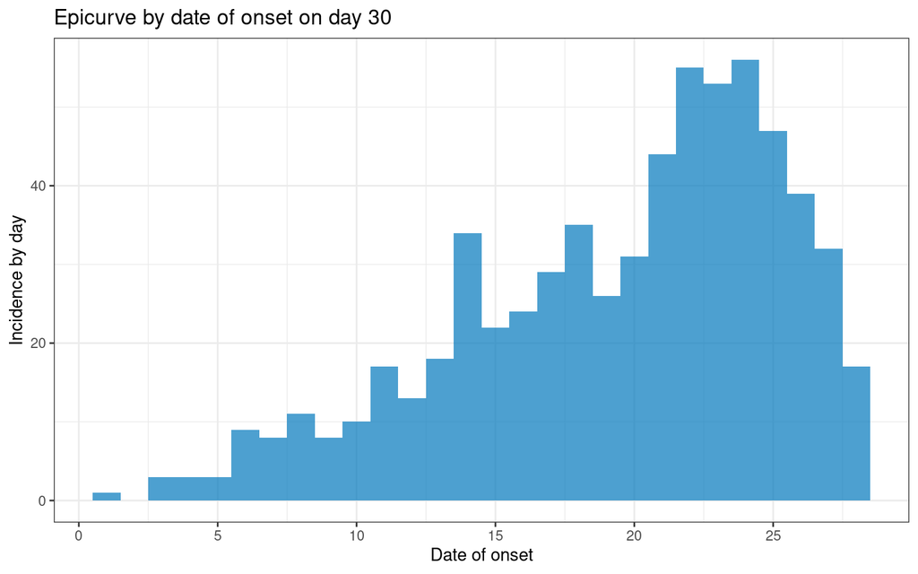

```r
## on day 30
data %>%
  filter(date_report < 30) %>%
  incidence(date_onset) %>%
  plot() +
  labs(title = "Epicurve by date of onset on day 30",
       x = "Date of onset")
```

The last figure suggests a sharp decrease in cases. In fact, this decrease is entirely artificial, and due to the fact that many cases have not yet been reported.

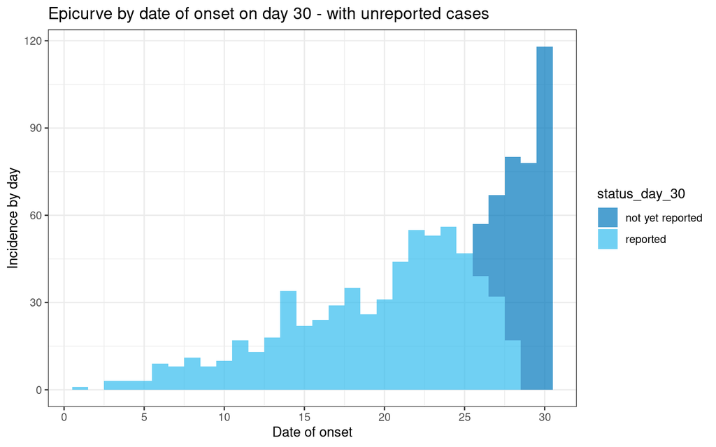

```r
## curve by date of onset
data %>%
  mutate(status_day_30 =
           if_else(
             date_report < 30,
             "reported",
             "not yet reported")) %>%
  incidence(date_onset, groups = status_day_30) %>%
  filter(date_index <= 30) %>%
  plot(fill = status_day_30) +
  labs(title = "Epicurve by date of onset on day 30 - with unreported cases", x
       = "Date of onset")
```

The issue is even stronger when considering dates of infection.

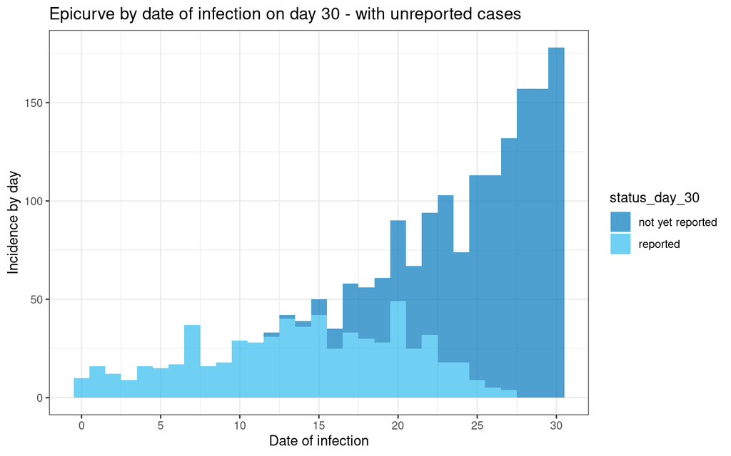

```r
## curve by date of infection
data %>%
  mutate(status_day_30 =
           if_else(
             date_report < 30,
             "reported",
             "not yet reported")) %>%
  incidence(date_infection, groups = status_day_30) %>%
  filter(date_index <= 30) %>%
  plot(fill = status_day_30) +
  labs(title = "Epicurve by date of infection on day 30 - with unreported cases", x
       = "Date of infection")
```